# Fetal Health Prediction

## Table Of Content

### 1. Introduction

#### 1.1 Report Overview

#### 1.2 Overview of Methodology

### 2. Predictive Modelling

#### 2.1 Feature Selection

#### 2.2 Model Fitting & Tuning

#### 2.3 Model Comparison

### 3. Critique & Limitations

### 4. Summary & Conclusions

#### 4.1 Project Summary

#### 4.2 Summary of Findings

#### 4.3 Conclusions

## Introduction

### Report Overview

#### Child Mortality is basially death of new born child under age of 5. The rate of child mortality is basically probability of dying between birth and exactly five years of age expressed per 1,000 live births. In this task we will be using fetal health dataset which has 2126 records of health features extracted from carditogram monitoring. The health features used are Heart rate ,fetal movement,uterine contractions,Decelerations and abnormal short-term variability.Thus, we wil be using above mentioned features to predict the fetal health and try to avoid further child and maternal mortality.

### Overview of Methodology

#### Feature selection is basically selecting informative features which can give good results while prediction.

#### After feature selection, the main process is to finalize the machine learning model, the initial stage before Modelling is to analyse the problem statement and to decide problem type. Thus, we are dealing with classification problem

#### Machine Learning models used for Classification: -

#### 1)KNN - K nearest neighbour algorithm is simplest algorithm which use data and classify new data points based on similarity measures (e.g., distance function)

#### 2)Logistic Regression - Logistic regression is a classification algorithm. It is used to predict a binary outcome based on a set of independent variables.

#### 3)Decision Tree - Decision Trees are a non-parametric supervised learning method used for both classification and regression tasks.

#### 4)Random Forest - Random Forest is combination of many decision trees which are made by bootstrapping of features to do prediction.

#### 5)Naive Bayes - Naive bayes classifiers are family of probabilistic classifier’s which are based on Bayes theorem.

#### 6)Support Vector Classifier - The SVC is a wrapper around the libsvm library and supports different kernels while LinearSVC is based on liblinear and only supports a linear kernel.

### Data Preprocessing

```python
#Importing required packages
import pandas as pd
import matplotlib.pyplot as plt
import seaborn as sns
import numpy as np
from sklearn.model_selection import train_test_split
from sklearn import linear_model
from sklearn.linear_model import LogisticRegression
from sklearn.neighbors import KNeighborsClassifier
from sklearn.ensemble import RandomForestClassifier
from sklearn.tree import DecisionTreeClassifier
from sklearn.naive_bayes import GaussianNB
from sklearn.model_selection import cross_val_score
from sklearn.pipeline import Pipeline
from sklearn.model_selection import RepeatedStratifiedKFold
from sklearn.model_selection import GridSearchCV
from sklearn.svm import SVC
from scipy import stats
from sklearn.metrics import confusion_matrix
from sklearn.metrics import classification_report
```

```python
#Creating The dataset variable
fetal_p = 'Data_group21.csv'
```

```python
#Reading the dataset and displaying the head
fetal = pd.read_csv(fetal_p)
fetal.head(10)
```

|  | baseline value | accelerations | fetal_movement | uterine_contractions | light_decelerations | severe_decelerations | prolongued_decelerations | abnormal_short_term_variability | mean_value_of_short_term_variability | percentage_of_time_with_abnormal_long_term_variability | ... | histogram_min | histogram_max | histogram_number_of_peaks | histogram_number_of_zeroes | histogram_mode | histogram_mean | histogram_median | histogram_variance | histogram_tendency | fetal_health |
| --- | --- | --- | --- | --- | --- | --- | --- | --- | --- | --- | --- | --- | --- | --- | --- | --- | --- | --- | --- | --- | --- |
| 0 | 120.0 | 0.000 | 0.0 | 0.000 | 0.000 | 0.0 | 0.000 | 73.0 | 0.5 | 43.0 | ... | 62.0 | 126.0 | 2.0 | 0.0 | 120.0 | 137.0 | 121.0 | 73.0 | 1.0 | 2.0 |
| 1 | 132.0 | 0.006 | 0.0 | 0.006 | 0.003 | 0.0 | 0.000 | 17.0 | 2.1 | 0.0 | ... | 68.0 | 198.0 | 6.0 | 1.0 | 141.0 | 136.0 | 140.0 | 12.0 | 0.0 | 1.0 |
| 2 | 133.0 | 0.003 | 0.0 | 0.008 | 0.003 | 0.0 | 0.000 | 16.0 | 2.1 | 0.0 | ... | 68.0 | 198.0 | 5.0 | 1.0 | 141.0 | 135.0 | 138.0 | 13.0 | 0.0 | 1.0 |
| 3 | 134.0 | 0.003 | 0.0 | 0.008 | 0.003 | 0.0 | 0.000 | 16.0 | 2.4 | 0.0 | ... | 53.0 | 170.0 | 11.0 | 0.0 | 137.0 | 134.0 | 137.0 | 13.0 | 1.0 | 1.0 |
| 4 | 132.0 | 0.007 | 0.0 | 0.008 | 0.000 | 0.0 | 0.000 | 16.0 | 2.4 | 0.0 | ... | 53.0 | 170.0 | 9.0 | 0.0 | 137.0 | 136.0 | 138.0 | 11.0 | 1.0 | 1.0 |
| 5 | 134.0 | 0.001 | 0.0 | 0.010 | 0.009 | 0.0 | 0.002 | 26.0 | 5.9 | 0.0 | ... | 50.0 | 200.0 | 5.0 | 3.0 | 76.0 | 107.0 | 107.0 | 170.0 | 0.0 | 3.0 |
| 6 | 134.0 | 0.001 | 0.0 | 0.013 | 0.008 | 0.0 | 0.003 | 29.0 | 6.3 | 0.0 | ... | 50.0 | 200.0 | 6.0 | 3.0 | 71.0 | 107.0 | 106.0 | 215.0 | 0.0 | 3.0 |
| 7 | 122.0 | 0.000 | 0.0 | 0.000 | 0.000 | 0.0 | 0.000 | 83.0 | 0.5 | 6.0 | ... | 62.0 | 130.0 | 0.0 | 0.0 | 122.0 | 122.0 | 123.0 | 3.0 | 1.0 | 3.0 |
| 8 | 122.0 | 0.000 | 0.0 | 0.002 | 0.000 | 0.0 | 0.000 | 84.0 | 0.5 | 5.0 | ... | 62.0 | 130.0 | 0.0 | 0.0 | 122.0 | 122.0 | 123.0 | 3.0 | 1.0 | 3.0 |
| 9 | 122.0 | 0.000 | 0.0 | 0.003 | 0.000 | 0.0 | 0.000 | 86.0 | 0.3 | 6.0 | ... | 62.0 | 130.0 | 1.0 | 0.0 | 122.0 | 122.0 | 123.0 | 1.0 | 1.0 | 3.0 |

10 rows × 22 columns

```python
#A small code to look at the type of data stored in each and every column
print(fetal.shape)
for i in range(22):
    print(type(fetal.iloc[0,i]))
```

```
(2126, 22)
<class 'numpy.float64'>
<class 'numpy.float64'>
<class 'numpy.float64'>
<class 'numpy.float64'>
<class 'numpy.float64'>
<class 'numpy.float64'>
<class 'numpy.float64'>
<class 'numpy.float64'>
<class 'numpy.float64'>
<class 'numpy.float64'>
<class 'numpy.float64'>
<class 'numpy.float64'>
<class 'numpy.float64'>
<class 'numpy.float64'>
<class 'numpy.float64'>
<class 'numpy.float64'>
<class 'numpy.float64'>
<class 'numpy.float64'>
<class 'numpy.float64'>
<class 'numpy.float64'>
<class 'numpy.float64'>
<class 'numpy.float64'>
```

```python
# Because we have all data as numerical hence describing the dataset Transposing for a better view
fetal.describe().T
```

|  | count | mean | std | min | 25% | 50% | 75% | max |
| --- | --- | --- | --- | --- | --- | --- | --- | --- |
| baseline value | 2126.0 | 133.303857 | 9.840844 | 106.0 | 126.000 | 133.000 | 140.000 | 160.000 |
| accelerations | 2126.0 | 0.003178 | 0.003866 | 0.0 | 0.000 | 0.002 | 0.006 | 0.019 |
| fetal_movement | 2126.0 | 0.009481 | 0.046666 | 0.0 | 0.000 | 0.000 | 0.003 | 0.481 |
| uterine_contractions | 2126.0 | 0.004366 | 0.002946 | 0.0 | 0.002 | 0.004 | 0.007 | 0.015 |
| light_decelerations | 2126.0 | 0.001889 | 0.002960 | 0.0 | 0.000 | 0.000 | 0.003 | 0.015 |
| severe_decelerations | 2126.0 | 0.000003 | 0.000057 | 0.0 | 0.000 | 0.000 | 0.000 | 0.001 |
| prolongued_decelerations | 2126.0 | 0.000159 | 0.000590 | 0.0 | 0.000 | 0.000 | 0.000 | 0.005 |
| abnormal_short_term_variability | 2126.0 | 46.990122 | 17.192814 | 12.0 | 32.000 | 49.000 | 61.000 | 87.000 |
| mean_value_of_short_term_variability | 2126.0 | 1.332785 | 0.883241 | 0.2 | 0.700 | 1.200 | 1.700 | 7.000 |
| percentage_of_time_with_abnormal_long_term_variability | 2126.0 | 9.846660 | 18.396880 | 0.0 | 0.000 | 0.000 | 11.000 | 91.000 |
| mean_value_of_long_term_variability | 2126.0 | 8.187629 | 5.628247 | 0.0 | 4.600 | 7.400 | 10.800 | 50.700 |
| histogram_width | 2126.0 | 70.445908 | 38.955693 | 3.0 | 37.000 | 67.500 | 100.000 | 180.000 |
| histogram_min | 2126.0 | 93.579492 | 29.560212 | 50.0 | 67.000 | 93.000 | 120.000 | 159.000 |
| histogram_max | 2126.0 | 164.025400 | 17.944183 | 122.0 | 152.000 | 162.000 | 174.000 | 238.000 |
| histogram_number_of_peaks | 2126.0 | 4.068203 | 2.949386 | 0.0 | 2.000 | 3.000 | 6.000 | 18.000 |
| histogram_number_of_zeroes | 2126.0 | 0.323612 | 0.706059 | 0.0 | 0.000 | 0.000 | 0.000 | 10.000 |
| histogram_mode | 2126.0 | 137.452023 | 16.381289 | 60.0 | 129.000 | 139.000 | 148.000 | 187.000 |
| histogram_mean | 2126.0 | 134.610536 | 15.593596 | 73.0 | 125.000 | 136.000 | 145.000 | 182.000 |
| histogram_median | 2126.0 | 138.090310 | 14.466589 | 77.0 | 129.000 | 139.000 | 148.000 | 186.000 |
| histogram_variance | 2126.0 | 18.808090 | 28.977636 | 0.0 | 2.000 | 7.000 | 24.000 | 269.000 |
| histogram_tendency | 2126.0 | 0.320320 | 0.610829 | -1.0 | 0.000 | 0.000 | 1.000 | 1.000 |
| fetal_health | 2126.0 | 1.304327 | 0.614377 | 1.0 | 1.000 | 1.000 | 1.000 | 3.000 |

```python
#checking dataset for the null values
fetal.isnull().sum()
```

```
baseline value                                            0
accelerations                                             0
fetal_movement                                            0
uterine_contractions                                      0
light_decelerations                                       0
severe_decelerations                                      0
prolongued_decelerations                                  0
abnormal_short_term_variability                           0
mean_value_of_short_term_variability                      0
percentage_of_time_with_abnormal_long_term_variability    0
mean_value_of_long_term_variability                       0
histogram_width                                           0
histogram_min                                             0
histogram_max                                             0
histogram_number_of_peaks                                 0
histogram_number_of_zeroes                                0
histogram_mode                                            0
histogram_mean                                            0
histogram_median                                          0
histogram_variance                                        0
histogram_tendency                                        0
fetal_health                                              0
dtype: int64
```

```python
#checking dataset for the na values(because its all numeric)
fetal.isna().sum()
```

```
baseline value                                            0
accelerations                                             0
fetal_movement                                            0
uterine_contractions                                      0
light_decelerations                                       0
severe_decelerations                                      0
prolongued_decelerations                                  0
abnormal_short_term_variability                           0
mean_value_of_short_term_variability                      0
percentage_of_time_with_abnormal_long_term_variability    0
mean_value_of_long_term_variability                       0
histogram_width                                           0
histogram_min                                             0
histogram_max                                             0
histogram_number_of_peaks                                 0
histogram_number_of_zeroes                                0
histogram_mode                                            0
histogram_mean                                            0
histogram_median                                          0
histogram_variance                                        0
histogram_tendency                                        0
fetal_health                                              0
dtype: int64
```

```python
# Getting The type of values in our target variable
fetal['fetal_health'].value_counts()
```

```
1.0    1655
2.0     295
3.0     176
Name: fetal_health, dtype: int64
```

```python
#As we are planing to do classification hence changing the target from numeric to labels
fetal['fetal_health'].replace({1.0 : "Normal" , 2.0: "Suspect" , 3.0 :"Pathalogical"},inplace = True)
fetal['fetal_health'].value_counts()
```

```
Normal          1655
Suspect          295
Pathalogical     176
Name: fetal_health, dtype: int64
```

## Predictive Modelling

### Scaling & Feature Selection

#### Feature selection is also called as variable selection. It is the process of selecting subset of relevant attributes which are in use for model construction.

#### The purpose of feature selection is to do simplification of models to make them easier to interpret by end users, it shortens the training time of model as unwanted features are separated and enhances generalisation by reducing overfitting.

#### Here, we have used k-best feature selection method, it selects features according to their highest score. Thus, the feature with higher score will be selected and rest features will be expelled.

```python
# assigning values to features as X and target as y
fetal_features=fetal.drop(["fetal_health"],axis=1)
fetal_target=fetal["fetal_health"]

from sklearn import preprocessing
from sklearn.preprocessing import StandardScaler

#Set up a Min Max scaler for the features
col_names = list(fetal_features.columns)
mm_scaler = preprocessing.MinMaxScaler()
fetal_features_scaled= mm_scaler.fit_transform(fetal_features)
fetal_features_scaled = pd.DataFrame(fetal_features_scaled, columns=col_names)
fetal_features_scaled.describe().T
```

|  | count | mean | std | min | 25% | 50% | 75% | max |
| --- | --- | --- | --- | --- | --- | --- | --- | --- |
| baseline value | 2126.0 | 0.505627 | 0.182238 | 0.0 | 0.370370 | 0.500000 | 0.629630 | 1.0 |
| accelerations | 2126.0 | 0.167277 | 0.203452 | 0.0 | 0.000000 | 0.105263 | 0.315789 | 1.0 |
| fetal_movement | 2126.0 | 0.019710 | 0.097018 | 0.0 | 0.000000 | 0.000000 | 0.006237 | 1.0 |
| uterine_contractions | 2126.0 | 0.291094 | 0.196405 | 0.0 | 0.133333 | 0.266667 | 0.466667 | 1.0 |
| light_decelerations | 2126.0 | 0.125964 | 0.197347 | 0.0 | 0.000000 | 0.000000 | 0.200000 | 1.0 |
| severe_decelerations | 2126.0 | 0.003293 | 0.057300 | 0.0 | 0.000000 | 0.000000 | 0.000000 | 1.0 |
| prolongued_decelerations | 2126.0 | 0.031703 | 0.117990 | 0.0 | 0.000000 | 0.000000 | 0.000000 | 1.0 |
| abnormal_short_term_variability | 2126.0 | 0.466535 | 0.229238 | 0.0 | 0.266667 | 0.493333 | 0.653333 | 1.0 |
| mean_value_of_short_term_variability | 2126.0 | 0.166586 | 0.129888 | 0.0 | 0.073529 | 0.147059 | 0.220588 | 1.0 |
| percentage_of_time_with_abnormal_long_term_variability | 2126.0 | 0.108205 | 0.202164 | 0.0 | 0.000000 | 0.000000 | 0.120879 | 1.0 |
| mean_value_of_long_term_variability | 2126.0 | 0.161492 | 0.111011 | 0.0 | 0.090730 | 0.145957 | 0.213018 | 1.0 |
| histogram_width | 2126.0 | 0.381050 | 0.220089 | 0.0 | 0.192090 | 0.364407 | 0.548023 | 1.0 |
| histogram_min | 2126.0 | 0.399812 | 0.271195 | 0.0 | 0.155963 | 0.394495 | 0.642202 | 1.0 |
| histogram_max | 2126.0 | 0.362288 | 0.154691 | 0.0 | 0.258621 | 0.344828 | 0.448276 | 1.0 |
| histogram_number_of_peaks | 2126.0 | 0.226011 | 0.163855 | 0.0 | 0.111111 | 0.166667 | 0.333333 | 1.0 |
| histogram_number_of_zeroes | 2126.0 | 0.032361 | 0.070606 | 0.0 | 0.000000 | 0.000000 | 0.000000 | 1.0 |
| histogram_mode | 2126.0 | 0.609858 | 0.128987 | 0.0 | 0.543307 | 0.622047 | 0.692913 | 1.0 |
| histogram_mean | 2126.0 | 0.565234 | 0.143061 | 0.0 | 0.477064 | 0.577982 | 0.660550 | 1.0 |
| histogram_median | 2126.0 | 0.560462 | 0.132721 | 0.0 | 0.477064 | 0.568807 | 0.651376 | 1.0 |
| histogram_variance | 2126.0 | 0.069919 | 0.107724 | 0.0 | 0.007435 | 0.026022 | 0.089219 | 1.0 |
| histogram_tendency | 2126.0 | 0.660160 | 0.305414 | 0.0 | 0.500000 | 0.500000 | 1.000000 | 1.0 |

```python
fetal_features_scaled.head(10)
```

|  | baseline value | accelerations | fetal_movement | uterine_contractions | light_decelerations | severe_decelerations | prolongued_decelerations | abnormal_short_term_variability | mean_value_of_short_term_variability | percentage_of_time_with_abnormal_long_term_variability | ... | histogram_width | histogram_min | histogram_max | histogram_number_of_peaks | histogram_number_of_zeroes | histogram_mode | histogram_mean | histogram_median | histogram_variance | histogram_tendency |
| --- | --- | --- | --- | --- | --- | --- | --- | --- | --- | --- | --- | --- | --- | --- | --- | --- | --- | --- | --- | --- | --- |
| 0 | 0.259259 | 0.000000 | 0.0 | 0.000000 | 0.000000 | 0.0 | 0.0 | 0.813333 | 0.044118 | 0.472527 | ... | 0.344633 | 0.110092 | 0.034483 | 0.111111 | 0.0 | 0.472441 | 0.587156 | 0.403670 | 0.271375 | 1.0 |
| 1 | 0.481481 | 0.315789 | 0.0 | 0.400000 | 0.200000 | 0.0 | 0.0 | 0.066667 | 0.279412 | 0.000000 | ... | 0.717514 | 0.165138 | 0.655172 | 0.333333 | 0.1 | 0.637795 | 0.577982 | 0.577982 | 0.044610 | 0.5 |
| 2 | 0.500000 | 0.157895 | 0.0 | 0.533333 | 0.200000 | 0.0 | 0.0 | 0.053333 | 0.279412 | 0.000000 | ... | 0.717514 | 0.165138 | 0.655172 | 0.277778 | 0.1 | 0.637795 | 0.568807 | 0.559633 | 0.048327 | 0.5 |
| 3 | 0.518519 | 0.157895 | 0.0 | 0.533333 | 0.200000 | 0.0 | 0.0 | 0.053333 | 0.323529 | 0.000000 | ... | 0.644068 | 0.027523 | 0.413793 | 0.611111 | 0.0 | 0.606299 | 0.559633 | 0.550459 | 0.048327 | 1.0 |
| 4 | 0.481481 | 0.368421 | 0.0 | 0.533333 | 0.000000 | 0.0 | 0.0 | 0.053333 | 0.323529 | 0.000000 | ... | 0.644068 | 0.027523 | 0.413793 | 0.500000 | 0.0 | 0.606299 | 0.577982 | 0.559633 | 0.040892 | 1.0 |
| 5 | 0.518519 | 0.052632 | 0.0 | 0.666667 | 0.600000 | 0.0 | 0.4 | 0.186667 | 0.838235 | 0.000000 | ... | 0.830508 | 0.000000 | 0.672414 | 0.277778 | 0.3 | 0.125984 | 0.311927 | 0.275229 | 0.631970 | 0.5 |
| 6 | 0.518519 | 0.052632 | 0.0 | 0.866667 | 0.533333 | 0.0 | 0.6 | 0.226667 | 0.897059 | 0.000000 | ... | 0.830508 | 0.000000 | 0.672414 | 0.333333 | 0.3 | 0.086614 | 0.311927 | 0.266055 | 0.799257 | 0.5 |
| 7 | 0.296296 | 0.000000 | 0.0 | 0.000000 | 0.000000 | 0.0 | 0.0 | 0.946667 | 0.044118 | 0.065934 | ... | 0.367232 | 0.110092 | 0.068966 | 0.000000 | 0.0 | 0.488189 | 0.449541 | 0.422018 | 0.011152 | 1.0 |
| 8 | 0.296296 | 0.000000 | 0.0 | 0.133333 | 0.000000 | 0.0 | 0.0 | 0.960000 | 0.044118 | 0.054945 | ... | 0.367232 | 0.110092 | 0.068966 | 0.000000 | 0.0 | 0.488189 | 0.449541 | 0.422018 | 0.011152 | 1.0 |
| 9 | 0.296296 | 0.000000 | 0.0 | 0.200000 | 0.000000 | 0.0 | 0.0 | 0.986667 | 0.014706 | 0.065934 | ... | 0.367232 | 0.110092 | 0.068966 | 0.055556 | 0.0 | 0.488189 | 0.449541 | 0.422018 | 0.003717 | 1.0 |

10 rows × 21 columns

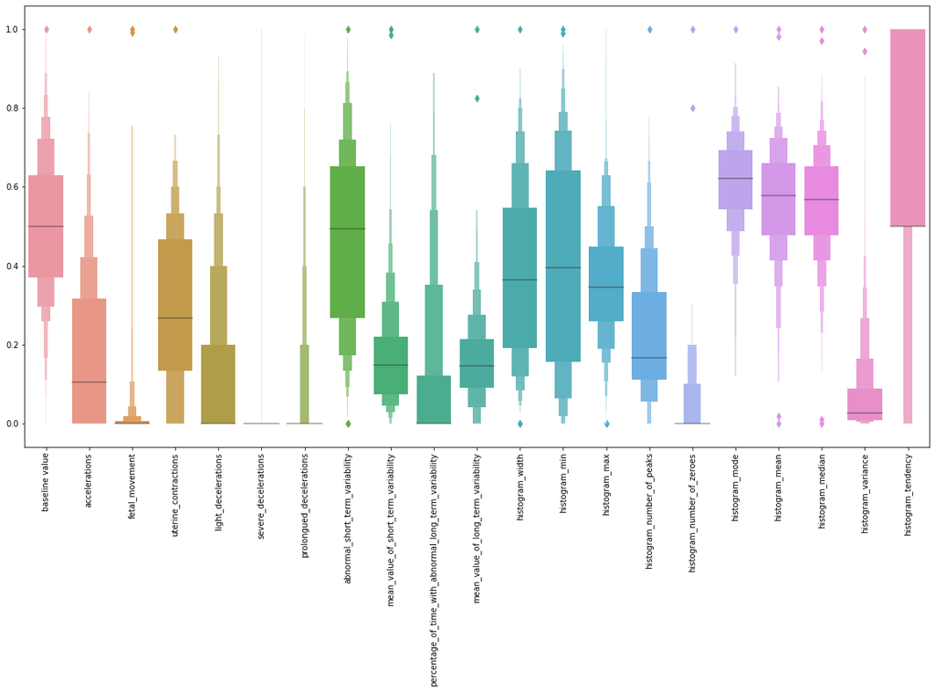

```python
#looking at the scaled features
# We can see all our features are in range for 0-1
plt.figure(figsize=(20,10))
sns.boxenplot(data = fetal_features_scaled)
plt.xticks(rotation=90)
plt.show()
```

```python
#Determining the scores for each of the three features for prediction
from sklearn.feature_selection import SelectKBest
from sklearn import feature_selection as fs



#Input columns
X = fetal_features_scaled
#Target column i.e Activity label
y = fetal_target



#Applying SelectKBest class to extract feature scores
bestfeatures = SelectKBest(fs.f_classif)
fit = bestfeatures.fit(X,y)
dfscores = pd.DataFrame(fit.scores_)
dfcolumns = pd.DataFrame(X.columns)
featureScores = pd.concat([dfcolumns,dfscores],axis=1)
featureScores.columns = ['Specs','Score']
```

```python
featureScores.sort_values('Score', ascending=False)
```

|  | Specs | Score |
| --- | --- | --- |
| 6 | prolongued_decelerations | 505.853206 |
| 9 | percentage_of_time_with_abnormal_long_term_var... | 345.156385 |
| 7 | abnormal_short_term_variability | 343.820419 |
| 17 | histogram_mean | 297.625497 |
| 16 | histogram_mode | 275.117696 |
| 18 | histogram_median | 248.772237 |
| 1 | accelerations | 196.027523 |
| 19 | histogram_variance | 150.796849 |
| 0 | baseline value | 140.621076 |
| 8 | mean_value_of_short_term_variability | 119.882006 |
| 3 | uterine_contractions | 93.715743 |
| 12 | histogram_min | 87.340503 |
| 10 | mean_value_of_long_term_variability | 70.174093 |
| 4 | light_decelerations | 66.864754 |
| 11 | histogram_width | 55.088241 |
| 20 | histogram_tendency | 44.542294 |
| 5 | severe_decelerations | 28.448156 |
| 14 | histogram_number_of_peaks | 12.104834 |
| 2 | fetal_movement | 11.679797 |
| 13 | histogram_max | 2.464923 |
| 15 | histogram_number_of_zeroes | 2.196373 |

```python
fetal_features_scaled_input =fetal_features_scaled[['prolongued_decelerations','percentage_of_time_with_abnormal_long_term_variability',
                                                    'abnormal_short_term_variability','histogram_mean','histogram_mode',
                                                    'histogram_median','accelerations','histogram_variance','baseline value',
                                                    'mean_value_of_short_term_variability']]
```

```python
fetal_features_scaled_input.head(10)
```

|  | prolongued_decelerations | percentage_of_time_with_abnormal_long_term_variability | abnormal_short_term_variability | histogram_mean | histogram_mode | histogram_median | accelerations | histogram_variance | baseline value | mean_value_of_short_term_variability |
| --- | --- | --- | --- | --- | --- | --- | --- | --- | --- | --- |
| 0 | 0.0 | 0.472527 | 0.813333 | 0.587156 | 0.472441 | 0.403670 | 0.000000 | 0.271375 | 0.259259 | 0.044118 |
| 1 | 0.0 | 0.000000 | 0.066667 | 0.577982 | 0.637795 | 0.577982 | 0.315789 | 0.044610 | 0.481481 | 0.279412 |
| 2 | 0.0 | 0.000000 | 0.053333 | 0.568807 | 0.637795 | 0.559633 | 0.157895 | 0.048327 | 0.500000 | 0.279412 |
| 3 | 0.0 | 0.000000 | 0.053333 | 0.559633 | 0.606299 | 0.550459 | 0.157895 | 0.048327 | 0.518519 | 0.323529 |
| 4 | 0.0 | 0.000000 | 0.053333 | 0.577982 | 0.606299 | 0.559633 | 0.368421 | 0.040892 | 0.481481 | 0.323529 |
| 5 | 0.4 | 0.000000 | 0.186667 | 0.311927 | 0.125984 | 0.275229 | 0.052632 | 0.631970 | 0.518519 | 0.838235 |
| 6 | 0.6 | 0.000000 | 0.226667 | 0.311927 | 0.086614 | 0.266055 | 0.052632 | 0.799257 | 0.518519 | 0.897059 |
| 7 | 0.0 | 0.065934 | 0.946667 | 0.449541 | 0.488189 | 0.422018 | 0.000000 | 0.011152 | 0.296296 | 0.044118 |
| 8 | 0.0 | 0.054945 | 0.960000 | 0.449541 | 0.488189 | 0.422018 | 0.000000 | 0.011152 | 0.296296 | 0.044118 |
| 9 | 0.0 | 0.065934 | 0.986667 | 0.449541 | 0.488189 | 0.422018 | 0.000000 | 0.003717 | 0.296296 | 0.014706 |

### KNN Fitting and Hyperparameter Tuning

#### The hyper parameters tuned for KNN classifier are n_neighbors and p (metric).

```python
cv_method = RepeatedStratifiedKFold(n_splits=5,
                                    n_repeats=3,
                                    random_state=999)
params_KNN = {'n_neighbors': [1,2, 3,4, 5,6, 7],
              'p': [1, 2, 5]}
gs_KNN = GridSearchCV(estimator=KNeighborsClassifier(),
                      param_grid=params_KNN,
                      cv=cv_method,
                      verbose=1,  # verbose: the higher, the more messages
                      scoring='accuracy',
                      return_train_score=True)
gs_KNN.fit(fetal_features_scaled_input, fetal_target);
```

```
Fitting 15 folds for each of 21 candidates, totalling 315 fits
```

```
[Parallel(n_jobs=1)]: Using backend SequentialBackend with 1 concurrent workers.
[Parallel(n_jobs=1)]: Done 315 out of 315 | elapsed:   48.0s finished
```

```python
gs_KNN.best_params_
```

```
{'n_neighbors': 1, 'p': 1}
```

```python
gs_KNN.best_score_
```

```
0.9327382859246984
```

```python
results_KNN = pd.DataFrame(gs_KNN.cv_results_['params'])
results_KNN['test_score'] = gs_KNN.cv_results_['mean_test_score']
results_KNN['metric'] = results_KNN['p'].replace([1,2,5], ["Manhattan", "Euclidean", "Minkowski"])
```

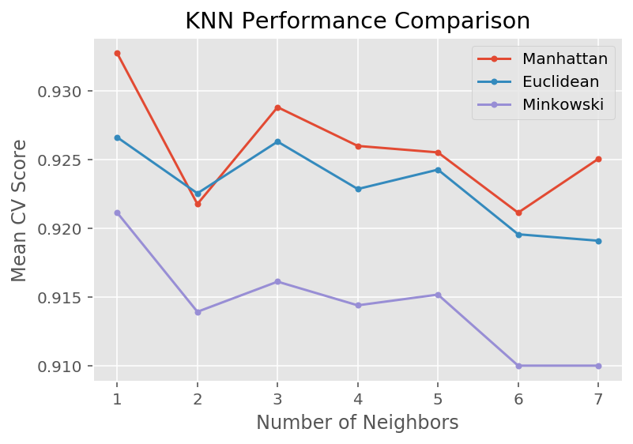

```python
import matplotlib.pyplot as plt
%matplotlib inline
%config InlineBackend.figure_format = 'retina'
plt.style.use("ggplot")

for i in ["Manhattan", "Euclidean", "Minkowski"]:
    temp = results_KNN[results_KNN['metric'] == i]
    plt.plot(temp['n_neighbors'], temp['test_score'], marker = '.', label = i)

plt.legend()
plt.xlabel('Number of Neighbors')
plt.ylabel("Mean CV Score")
plt.title("KNN Performance Comparison")
plt.show()
```

### Decision Tree Fitting & HyperParameter Tunning

#### The hyper parameters tuned for Decision Tree classifier are criterion, max_depth and min_samples_split.

```python
df_classifier = DecisionTreeClassifier(random_state=999)

params_DT = {'criterion': ['gini', 'entropy'],
             'max_depth': [1, 2, 3, 4, 5, 6, 7, 8],
             'min_samples_split': [3,4,5]}

gs_DT = GridSearchCV(estimator=df_classifier,
                     param_grid=params_DT,
                     cv=cv_method,
                     verbose=1,
                     scoring='accuracy')

gs_DT.fit(fetal_features_scaled_input, fetal_target);
```

```
Fitting 15 folds for each of 48 candidates, totalling 720 fits
```

```
[Parallel(n_jobs=1)]: Using backend SequentialBackend with 1 concurrent workers.
[Parallel(n_jobs=1)]: Done 720 out of 720 | elapsed:    8.1s finished
```

```python
gs_DT.best_params_
```

```
{'criterion': 'entropy', 'max_depth': 7, 'min_samples_split': 4}
```

```python
gs_DT.best_score_
```

```
0.9302292184479425
```

```python
results_DT = pd.DataFrame(gs_DT.cv_results_['params'])
results_DT['test_score'] = gs_DT.cv_results_['mean_test_score']
results_DT.columns
```

```
Index(['criterion', 'max_depth', 'min_samples_split', 'test_score'], dtype='object')
```

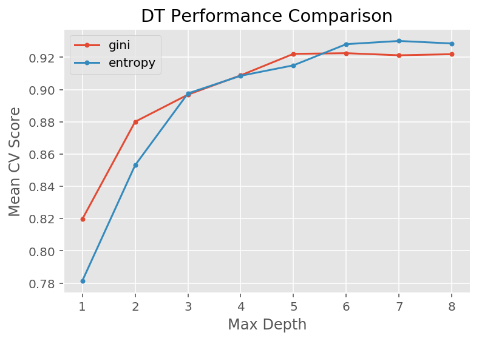

```python
for i in ['gini', 'entropy']:
    temp = results_DT[results_DT['criterion'] == i]
    temp_average = temp.groupby('max_depth').agg({'test_score': 'mean'})
    plt.plot(temp_average, marker = '.', label = i)


plt.legend()
plt.xlabel('Max Depth')
plt.ylabel("Mean CV Score")
plt.title("DT Performance Comparison")
plt.show()
```

#### We have found that the best parameters for Decision Tree classifier are criterion = entropy, max_depth = 7 and min_samples_split = 4

### Naive Bayes Model Fitting & HyperParameter tuning

```python
np.random.seed(999)

nb_classifier = GaussianNB()

params_NB = {'var_smoothing': np.logspace(0,-9, num=100)}

gs_NB = GridSearchCV(estimator=nb_classifier,
                     param_grid=params_NB,
                     cv=cv_method,
                     verbose=1,
                     scoring='accuracy')

gs_NB.fit(fetal_features_scaled_input, fetal_target);
```

```
Fitting 15 folds for each of 100 candidates, totalling 1500 fits
```

```
[Parallel(n_jobs=1)]: Using backend SequentialBackend with 1 concurrent workers.
[Parallel(n_jobs=1)]: Done 1500 out of 1500 | elapsed:    9.7s finished
```

```python
gs_NB.best_params_
```

```
{'var_smoothing': 0.533669923120631}
```

```python
gs_NB.best_score_
```

```
0.8639079443984167
```

```python
results_NB = pd.DataFrame(gs_NB.cv_results_['params'])
results_NB['test_score'] = gs_NB.cv_results_['mean_test_score']
```

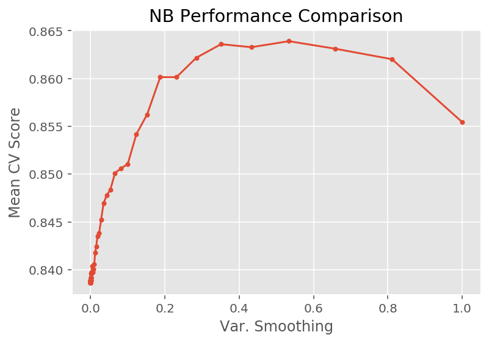

```python
plt.plot(results_NB['var_smoothing'], results_NB['test_score'], marker = '.')
plt.xlabel('Var. Smoothing')
plt.ylabel("Mean CV Score")
plt.title("NB Performance Comparison")
plt.show()
```

#### The best value for var_smoothing is found to be 0.533669923120631

### Random Forest Model Fitting & HyperParamter tuning

#### The hyper parameters tuned for Random Forest classifier are n_estimators and max_features.The n_estimators are set to logarithmic values and max_features refers to the function used for calculation.

```python
# define models and parameters
model = RandomForestClassifier()
n_estimators = [10, 100, 1000]
max_features = ['sqrt', 'log2']
# define grid search
grid = dict(n_estimators=n_estimators,max_features=max_features)
cv = RepeatedStratifiedKFold(n_splits=10, n_repeats=3, random_state=1)
grid_search = GridSearchCV(estimator=model, param_grid=grid, n_jobs=-1, cv=cv, scoring='accuracy',error_score=0)
grid_result = grid_search.fit(fetal_features_scaled_input, fetal_target)
# summarize results
print("Best: %f using %s" % (grid_result.best_score_, grid_result.best_params_))
```

```
Best: 0.948110 using {'max_features': 'log2', 'n_estimators': 100}
```

```python
results_RF = pd.DataFrame(grid_result.cv_results_['params'])
results_RF['test_score'] = grid_result.cv_results_['mean_test_score']
results_RF.columns
```

```
Index(['max_features', 'n_estimators', 'test_score'], dtype='object')
```

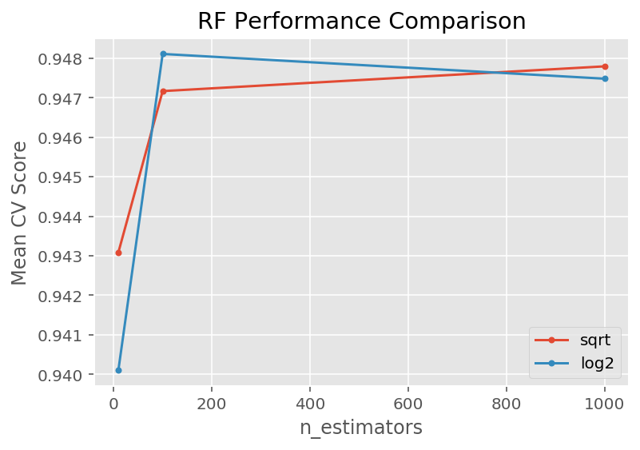

```python
for i in ['sqrt', 'log2']:
    temp = results_RF[results_RF['max_features'] == i]
    temp_average = temp.groupby('n_estimators').agg({'test_score': 'mean'})
    plt.plot(temp_average, marker = '.', label = i)


plt.legend()
plt.xlabel('n_estimators')
plt.ylabel("Mean CV Score")
plt.title("RF Performance Comparison")
plt.show()
```

### Support Vector Classifier modelling & Parameter Tuning

#### The hyper parameters tuned for SVC classifier are kernel, C and gamma.

```python
# define model and parameters
model = SVC()
kernel = ['poly', 'rbf', 'sigmoid']
C = [50, 10, 1.0, 0.1, 0.01]
gamma = ['scale']
# define grid search
grid = dict(kernel=kernel,C=C,gamma=gamma)
cv = RepeatedStratifiedKFold(n_splits=10, n_repeats=3, random_state=1)
grid_search = GridSearchCV(estimator=model, param_grid=grid, n_jobs=-1, cv=cv, scoring='accuracy',error_score=0)
grid_result = grid_search.fit(fetal_features_scaled_input, fetal_target)
# summarize results
print("Best: %f using %s" % (grid_result.best_score_, grid_result.best_params_))
```

```
Best: 0.927562 using {'C': 50, 'gamma': 'scale', 'kernel': 'rbf'}
```

```python
results_SVC = pd.DataFrame(grid_result.cv_results_['params'])
results_SVC['test_score'] = grid_result.cv_results_['mean_test_score']
results_SVC.columns
```

```
Index(['C', 'gamma', 'kernel', 'test_score'], dtype='object')
```

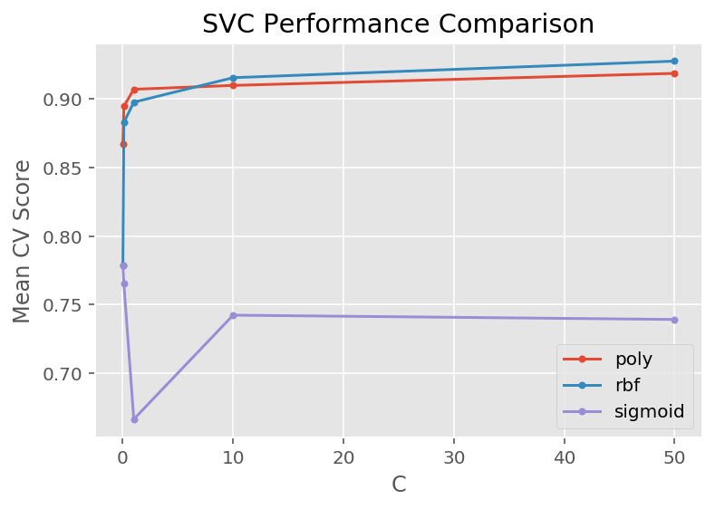

```python
for i in ['poly', 'rbf', 'sigmoid']:
    temp = results_SVC[results_SVC['kernel'] == i]
    temp_average = temp.groupby('C').agg({'test_score': 'mean'})
    plt.plot(temp_average, marker = '.', label = i)


plt.legend()
plt.xlabel('C')
plt.ylabel("Mean CV Score")
plt.title("SVC Performance Comparison")
plt.show()
```

#### The hyper parameters tuned for SVC classifier are C = 50, gamma = scale and kernel = rbf.

### Model Comparision

```python
# spliting test and training sets
# looking at the shapes of the splitted data sets
X_train, X_test, y_train,y_test = train_test_split(fetal_features_scaled_input,fetal_target,test_size=0.3,random_state=42)
X_train.shape, X_test.shape, y_train.shape, y_test.shape
```

```
((1488, 10), (638, 10), (1488,), (638,))
```

```python
#A quick model selection process
#pipelines of models( it is short was to fit and pred)
pipeline_lr=Pipeline([('lr_classifier',LogisticRegression(random_state=42))])

pipeline_knn = Pipeline([('knn_classifier',KNeighborsClassifier(3))])

pipeline_dt=Pipeline([ ('dt_classifier',DecisionTreeClassifier(criterion = 'entropy' , max_depth = 7 , min_samples_split = 4 ,random_state=42))])

pipeline_rf=Pipeline([('rf_classifier',RandomForestClassifier( max_features = 'sqrt' , n_estimators = 100))])

pipeline_nb = Pipeline([('nb_classifier',GaussianNB(var_smoothing=0.5336699))])

pipeline_svc = Pipeline([('svc_classifier',SVC(C= 50, gamma = 'scale', kernel = 'rbf'))])

# List of all the pipelines
pipelines = [pipeline_lr,pipeline_knn, pipeline_dt, pipeline_rf,pipeline_nb,pipeline_svc]

# Dictionary of pipelines and classifier types for ease of reference
pipe_dict = {0: 'Logistic Regression',1:'K Nearest Neighbors' ,2: 'Decision Tree', 3: 'RandomForest', 4: "Naive bayes" , 5:"Support Vector Classifier "}

# Generating the Classification Report & Confusion Matrix for each Algorithm
for i,pipe in enumerate(pipelines):
    fit = pipe.fit(X_train,y_train)
    y_pre = fit.predict(X_test)
    print("Confusion matrix for :" + pipe_dict[i] +"\n")

    print(confusion_matrix(y_test, y_pre))

    print("\nClassification Report for :" + pipe_dict[i] +"\n")

    print(classification_report(y_test,y_pre))


#cross validation on accuracy
print("\nCross Validation Results for our Algorithms")
cv_results_accuracy = []
for i, model in enumerate(pipelines):
    cv_score = cross_val_score(model, X_train,y_train, cv=10 )
    cv_results_accuracy.append(cv_score)
    print("%s: %f " % (pipe_dict[i], cv_score.mean()))
```

```
Confusion matrix for :Logistic Regression

[[479   2  15]
 [  6  30   5]
 [ 37   5  59]]

Classification Report for :Logistic Regression

              precision    recall  f1-score   support

      Normal       0.92      0.97      0.94       496
Pathalogical       0.81      0.73      0.77        41
     Suspect       0.75      0.58      0.66       101

    accuracy                           0.89       638
   macro avg       0.83      0.76      0.79       638
weighted avg       0.88      0.89      0.88       638

Confusion matrix for :K Nearest Neighbors

[[478   1  17]
 [  3  37   1]
 [ 21   5  75]]

Classification Report for :K Nearest Neighbors

              precision    recall  f1-score   support

      Normal       0.95      0.96      0.96       496
Pathalogical       0.86      0.90      0.88        41
     Suspect       0.81      0.74      0.77       101

    accuracy                           0.92       638
   macro avg       0.87      0.87      0.87       638
weighted avg       0.92      0.92      0.92       638

Confusion matrix for :Decision Tree

[[482   6   8]
 [  3  38   0]
```

[output cut: 61 more lines]

```
Pathalogical       0.88      0.93      0.90        41
     Suspect       0.73      0.83      0.78       101

    accuracy                           0.92       638
   macro avg       0.86      0.90      0.88       638
weighted avg       0.92      0.92      0.92       638


Cross Validation Results for our Algorithms
Logistic Regression: 0.875680
K Nearest Neighbors: 0.926769
Decision Tree: 0.907968
RandomForest: 0.934165
Naive bayes: 0.862257
Support Vector Classifier : 0.920053
```

```python
#saving the mean cross validation results for each algorithm for easy of interpretation and visulaization
cv_results_df = {'Algorithm' : ['Logistic Regression','K Nearest Neighbors' ,'Decision Tree','RandomForest',
                           "Naive bayes" ,"Support Vector Classifier "],
                   'Score' : [cv_results_accuracy[0].mean(),cv_results_accuracy[1].mean(),cv_results_accuracy[2].mean(),
                              cv_results_accuracy[3].mean(),cv_results_accuracy[4].mean(),cv_results_accuracy[5].mean()]}
cv_results_df = pd.DataFrame(cv_results_df)
cv_results_df
```

|  | Algorithm | Score |
| --- | --- | --- |
| 0 | Logistic Regression | 0.875680 |
| 1 | K Nearest Neighbors | 0.926769 |
| 2 | Decision Tree | 0.907968 |
| 3 | RandomForest | 0.934165 |
| 4 | Naive bayes | 0.862257 |
| 5 | Support Vector Classifier | 0.920053 |

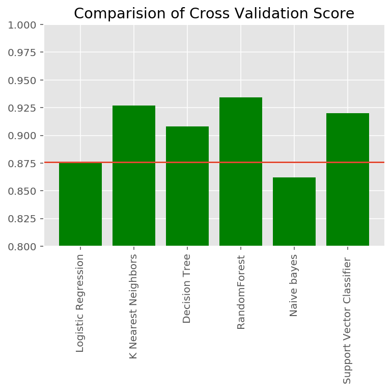

```python
# A bar graph showing the Cross Validation score of each algorithm
# Logistic regression being the bench mark model
plt.bar(cv_results_df['Algorithm'] , cv_results_df['Score'], color = 'green')
plt.xticks(rotation=90)
plt.title('Comparision of Cross Validation Score')
plt.axhline(y=0.875680)
plt.ylim([0.8,1])
plt.show()
```

#### We have also calculated the score of Logistic Regression algorithm with the other classifiers to set it as a baseline. The graph shows the comparison of the scores of the classifiers. It can be observed that the Random Forest scores the best out of all the classifiers. Naive Bayes is the lowest among the classifiers as it’s score is lower than the baseline score of Logistic Regression.